# PSTAT 231 HW2 muxi

muxi

2022-10-22

## PSTAT 231 Homework 2

## Question 1

```r
library(tidyverse)
library(tidymodels)
data=read.csv("abalone.csv")
head(data)
```

```
##   type longest_shell diameter height whole_weight shucked_weight viscera_weight
## 1    M         0.455    0.365  0.095       0.5140         0.2245         0.1010
## 2    M         0.350    0.265  0.090       0.2255         0.0995         0.0485
## 3    F         0.530    0.420  0.135       0.6770         0.2565         0.1415
## 4    M         0.440    0.365  0.125       0.5160         0.2155         0.1140
## 5    I         0.330    0.255  0.080       0.2050         0.0895         0.0395
## 6    I         0.425    0.300  0.095       0.3515         0.1410         0.0775
##   shell_weight rings
## 1        0.150    15
## 2        0.070     7
## 3        0.210     9
## 4        0.155    10
## 5        0.055     7
## 6        0.120     8
```

```r
data=mutate(data,age=rings+1.5)
summary(data$age)
```

```
##    Min. 1st Qu.  Median    Mean 3rd Qu.    Max.
##    2.50    9.50   10.50   11.43   12.50   30.50
```

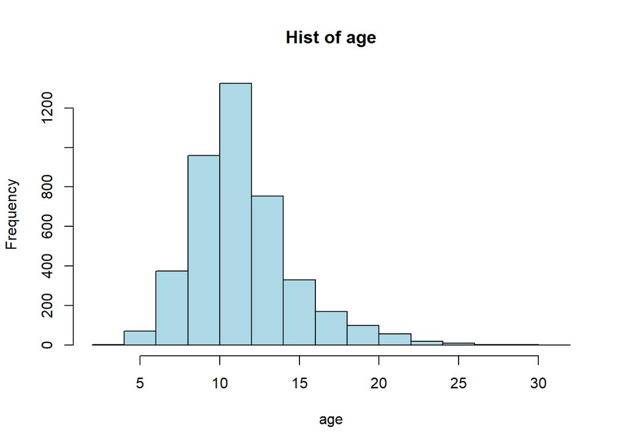

```r
hist(data$age,xlab="age",main="Hist of age",col="lightblue")
```

To begin with, I believe that age could be treated as quantitative predictor. Though rings are always integers, we could use the raw data as a estimate of the exact age.

From summary and hist graph, we could see that the age is right skewed and there is no obvious outlier.

## Question 2

```r
set.seed(1215)
data_split = initial_split(data, prop = 0.80)
data_train = training(data_split)
data_test = testing(data_split)
```

## Question 3

As age and rings are strongly positive correlated( age = rings + 1.5), the residuals plot would be a level line through residuals=0. This will remove error term, lead to overfitting and make any other predictors meaningless.

```r
#drop rings column
train=select(data_train,-c(rings))
test=select(data_test,-c(rings))
simple_data_recipe=recipe(age ~ ., data = train)
summary(simple_data_recipe)
```

```
## # A tibble: 9 × 4
##   variable       type    role      source
##   <chr>          <chr>   <chr>     <chr>
## 1 type           nominal predictor original
## 2 longest_shell  numeric predictor original
## 3 diameter       numeric predictor original
## 4 height         numeric predictor original
## 5 whole_weight   numeric predictor original
## 6 shucked_weight numeric predictor original
## 7 viscera_weight numeric predictor original
## 8 shell_weight   numeric predictor original
## 9 age            numeric outcome   original
```

```r
data_recipe = recipe(age~ ., data = train)
recipe=data_recipe%>%
  step_dummy(all_nominal_predictors())%>%
  step_interact(terms = ~ starts_with("type"):shucked_weight)%>%
  step_interact(terms = ~ longest_shell:diameter)%>%
  step_interact(terms = ~ shucked_weight:shell_weight)%>%
  step_center(all_nominal_predictors())%>%
  step_scale(all_nominal_predictors())
```

## Question 4

```r
lm_model = linear_reg() %>%
  set_engine("lm")
```

## Question 5

```r
lm_wflow = workflow() %>%
  add_model(lm_model) %>%
  add_recipe(recipe)
lm_fit = fit(lm_wflow, train)
summary(lm_fit)
```

```
##         Length Class      Mode
## pre     3      stage_pre  list
## fit     2      stage_fit  list
## post    1      stage_post list
## trained 1      -none-     logical
```

## Question 6

```r
pre=train[1,]
pre[2:8]=c(0.5,0.1,0.3,4,1,2,1)
predict(lm_fit, pre)
```

```
## # A tibble: 1 × 1
##   .pred
##   <dbl>
## 1  24.6
```

## Question 7

```r
library(yardstick)
train_res = predict(lm_fit, new_data =train %>% select(-age))
#predicted values vs the actual observed ages
train_res = bind_cols(train_res, train %>% select(age))
train_res %>%
  head()
```

```
## # A tibble: 6 × 2
##   .pred   age
##   <dbl> <dbl>
## 1 13.9   18.5
## 2  8.61   8.5
## 3 11.2    9.5
## 4 13.2   14.5
## 5 11.0   13.5
## 6  9.17   8.5
```

```r
#R2, RMSE, and MAE
metrics = metric_set(rmse, rsq, mae)
metrics(train_res, truth = age, estimate = .pred)
```

```
## # A tibble: 3 × 3
##   .metric .estimator .estimate
##   <chr>   <chr>          <dbl>
## 1 rmse    standard       2.12
## 2 rsq     standard       0.564
## 3 mae     standard       1.54
```

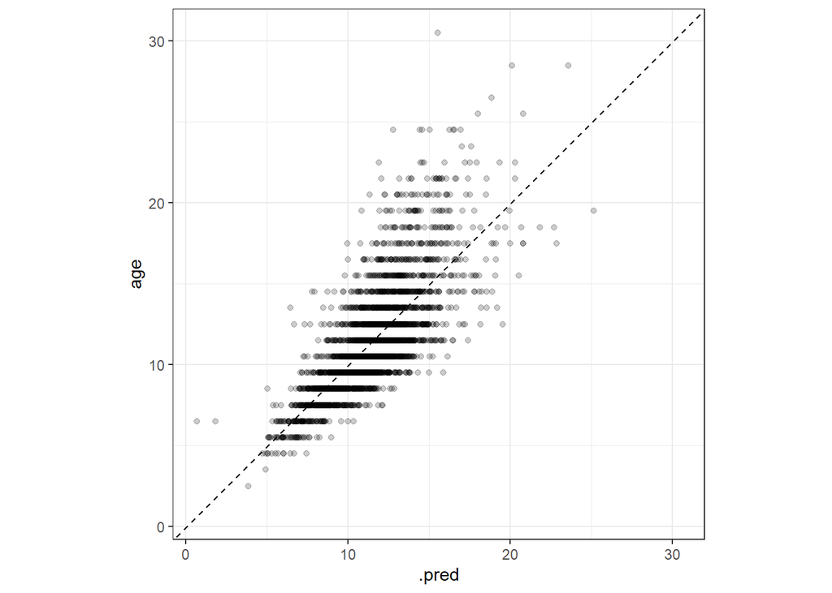

```r
train_res %>%
  ggplot(aes(x = .pred, y = age)) +
  geom_point(alpha = 0.2) +
  geom_abline(lty = 2) +
  theme_bw() +
  coord_obs_pred()
```

From R-square and plot, we could see that the model didn’t do very well. If it predicted every observation accurately, the dots would form a straight line. Perhaps in the future, I will try other models and other interaction methods dealing with type and shucked_weight.

## Question 8

Reproducible errors are $Var(\hat{f}(x_{0}))$, $[Bias(\hat{f}(x_{0}))]^2$.

Irreducible error is $Var(\epsilon)$.

## Question 9

$\because Var(\hat{f}(x_{0}))>0,[Bias(\hat{f}(x_{0}))]^2>0$

$\therefore E[(y_{0}-\hat{f}(x_{0}))^2]\geq Var(\epsilon)$

## Question 10

$E[(y_{0}-\hat{f}(x_{0}))^2]=E[y_{0}^2]-2E[y_{0}]E[\hat{f}(x_{0})]+E[\hat{f}(x_{0})^2]\\=Var(\epsilon)+E[y_{0}]^2-2E[y_{0}]E[\hat{f}(x_{0})]+E[\hat{f}(x_{0})]^2-E[\hat{f}(x_{0})]^2+E[\hat{f}(x_{0})^2]\\=Var(\epsilon)+(E[\hat{f}(x_{0})]-y_{0})^2+Var(\hat{f}(x_{0}))\\=Var(\epsilon)+[Bias(\hat{f}(x_{0}))]^2+Var(\hat{f}(x_{0}))$